# PQ Report Generator

# Negative Samples

Raw RFU.Range data of Panel A and Negative Control (if present):

|  | Sample.Name | Flag | FusionTestOrder | test.order | WellID | replicate | FAM.ct | FAM.tslope | FAM.rr | FAM.eb | FAM.Result | HEX.ct | HEX.tslope | HEX.rr | HEX.eb | HEX.Result | IC.ct | IC.tslope | IC.rr | IC.eb | IC.Result | RED647.ct | RED647.tslope | RED647.rr | RED647.eb | RED647.Result | ROX.ct | ROX.tslope | ROX.rr | … |
| --- | --- | --- | --- | --- | --- | --- | --- | --- | --- | --- | --- | --- | --- | --- | --- | --- | --- | --- | --- | --- | --- | --- | --- | --- | --- | --- | --- | --- | --- | --- |
| 1 | Negative Control - Lot 134187 | IUO | 8201 | 8202 | 01-01 | 1 | NA | NA | 52 | 6794 | NEG | NA | NA | -26 | 3755.55 | NEG | 30.75 | 280.349999999999 | 9368 | 7758.01363103152 | POS | NA | NA | 34 | 3692.7 | NEG | NA | NA | 25 | … |
| 2 | NEGATIVE-001 | IUO | 8164 | 8165 | 01-03 | 1 | NA | NA | 42 | 5238 | NEG | NA | NA | 19 | 2628.18333333333 | NEG | 32.01 | 372.75 | 9826 | 5198.73331261828 | POS | NA | NA | 35 | 2571.9 | NEG | NA | NA | 5 | … |
| 3 | NEGATIVE-001 | IUO | 8164 | 8166 | 01-04 | 2 | NA | NA | -53 | 5515.95 | NEG | NA | NA | 18 | 2821.05 | NEG | 31.84 | 249.150000000001 | 11192 | 5412.35406944763 | POS | NA | NA | 24 | 2756.05 | NEG | NA | NA | -9 | … |
| 4 | NEGATIVE-001 | IUO | 8164 | 8167 | 01-05 | 3 | NA | NA | -43 | 5796.25 | NEG | NA | NA | 27 | 2865.65 | NEG | 31.89 | 252.95 | 11315 | 5438.19704258014 | POS | NA | NA | 30 | 2831.7 | NEG | NA | NA | -13 | … |
| 5 | NEGATIVE-002 | IUO | 8173 | 8174 | 02-01 | 1 | NA | NA | 48 | 5615.66666666667 | NEG | NA | NA | -18 | 2827.7 | NEG | 32.29 | 361.299999999999 | 11389 | 5897.31004576779 | POS | NA | NA | 32 | 2772.75 | NEG | NA | NA | -19 | … |
| 6 | NEGATIVE-002 | IUO | 8173 | 8175 | 02-02 | 2 | NA | NA | 90 | 6470.73333333333 | NEG | NA | NA | -40 | 3359.25 | NEG | 32.07 | 460.099999999999 | 13235 | 6923.53086995377 | POS | NA | NA | -32 | 3186.95 | NEG | NA | NA | 19 | … |
| 7 | NEGATIVE-002 | IUO | 8173 | 8176 | 02-03 | 3 | NA | NA | 25 | 4840.6 | NEG | NA | NA | -31 | 2109.11666666667 | NEG | 32.54 | 308.3 | 8454 | 4155.39777503819 | POS | NA | NA | -27 | 2072.3 | NEG | NA | NA | -10 | … |
| 8 | NEGATIVE-003 | IUO | 8133 | 8138 | 02-04 | 1 | NA | NA | -51 | 5606.6 | NEG | NA | NA | 21 | 2667.28333333333 | NEG | 32.06 | 391.099999999999 | 10162 | 5127.85967214465 | POS | NA | NA | 22 | 2578.9 | NEG | NA | NA | -10 | … |
| 9 | NEGATIVE-003 | IUO | 8133 | 8149 | 02-05 | 2 | NA | NA | 55 | 6468.4 | NEG | NA | NA | -16 | 3245.88333333333 | NEG | 31.84 | 266.45 | 12329 | 6556.44567111497 | POS | NA | NA | 43 | 3217.4 | NEG | NA | NA | 9 | … |
| 10 | NEGATIVE-003 | IUO | 8133 | 8153 | 03-01 | 3 | NA | NA | -58 | 6439.95 | NEG | NA | NA | 23 | 3223.7 | NEG | 31.68 | 293.15 | 12162 | 6850.15442708615 | POS | NA | NA | 52 | 3242.15 | NEG | NA | NA | 13 | … |

[output cut: 55 more lines]

# Summary Plots

## RFU Range

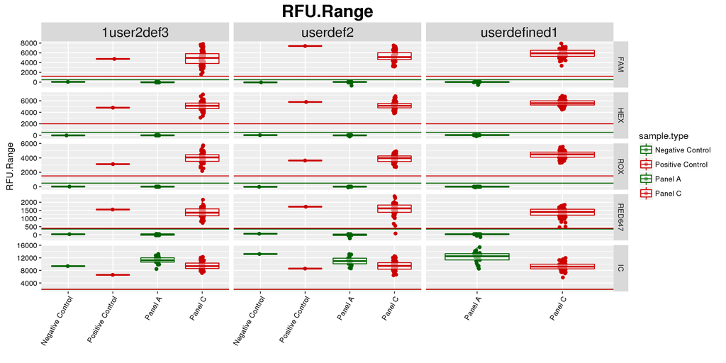

## Ct Non-Normalized

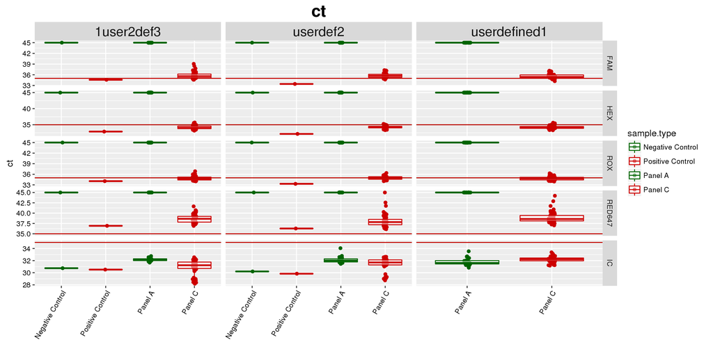

## Estimated Baseline

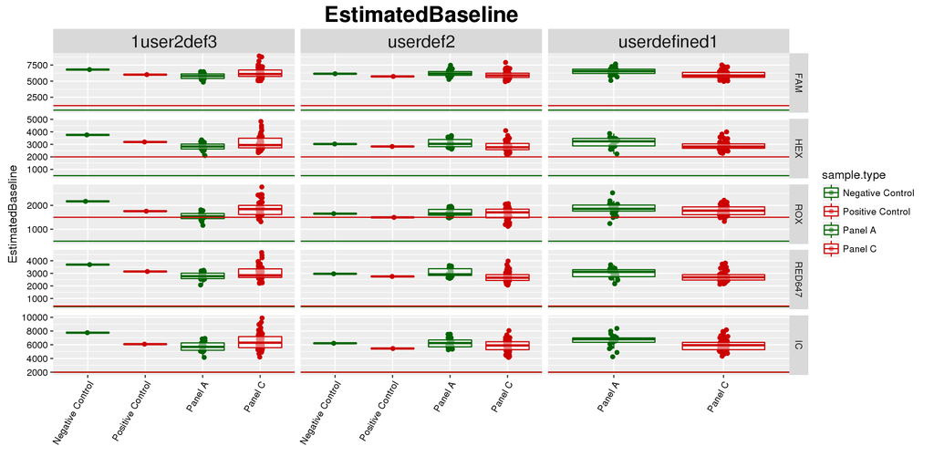